# Subgroup Identification Exploration

Larry Leon

# Post-hoc Subgroup Identification Analyses

Exploratory subgroup analyses for the *ESCC* population based on overall survival outcomes will be conducted.

- The following baseline factors were considered:
1. `Region: Asia vs non-Asia`
2. `Age (continuous)`
3. `Age <65yrs / >=65Yrs`
4. `Male/Female`
5. `Ecog 0/1`
6. `Liver mets`
7. `Metastatic`
8. `Tumor size`
9. `Chemo (5-FU + cisplatin vs CAPOX)`
10. `CPS>=1, CPS>=5, CPS>=10`
11. `CPS>1, CPS>5, CPS>10, CPS>15`
12. `CPS (continuous)`

## Executive Summary of Identified Subgroups (non-stratified Cox)

Post-hoc subgroup analyses identified subgroups based on CPS cuts alone and in combination with tumor size (“>=1”, “>1”, “>3”, “tumor_size>19”, “tumor_size>62”). Cross-validation assessments of *reproducibility* suggests the algorithm corresponding to the identification of the subgroup **CPS>1 and tumor_size>19** as **benefiting** appears to have (relatively) favorable properties. Though we note that the cross-validation (CV) summary of reproducibility is in the $75\%$ range which may be borderline performance (e.g., ~ $76\%$ of the **CPS>1 and tumor_size>19** subjects classified as **benefiting** were also classified as benefiting in the CV testing sample [See `OS Subgroups Identified’ section below]).

- Overall Survival–
  - Overall (SCC, n=548) population: hr=0.72 (0.59-0.87)
    - note that n=15 subjects had missing CPS
  - Subjects with CPS>1 and tumor_size>19 (n=363):
    - *adjusted* hr=0.63 (0.47-0.84)
  - Subjects with CPS<=1 or tumor_size<=19 (n=170):
    - *adjusted* hr=0.94 (0.58-1.52)

The *adjusted* hazard-ratio estimates and confidence intervals account for the subgroup identification algorithm.

The ITT and subgroup Kaplan-Meier estimates are below (Note that K-M and Cox estimates in Figures (b) and (c) do not account for the subgroup identification)

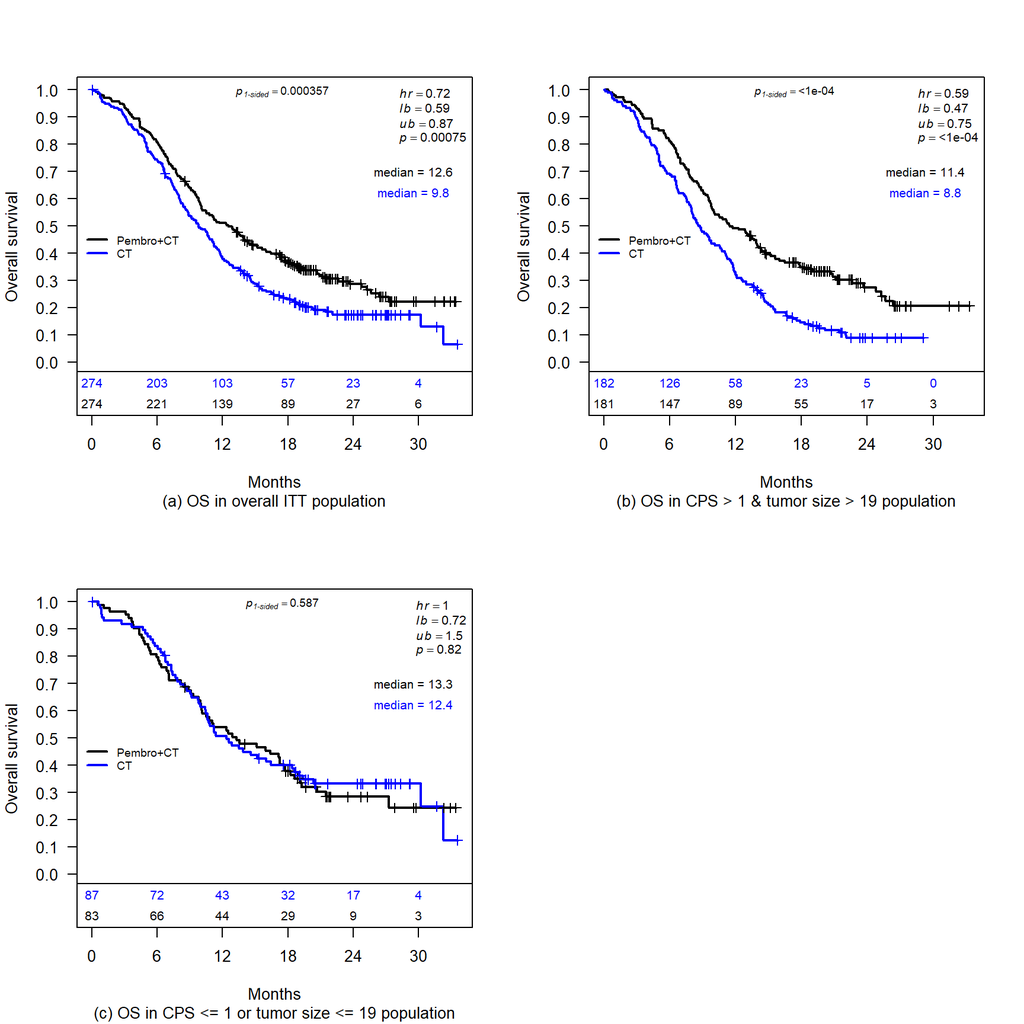

### Forestplot by CPS levels

Hazard ratio estimates by subgroups based on CPS levels (as conducted in recent FDA summary):

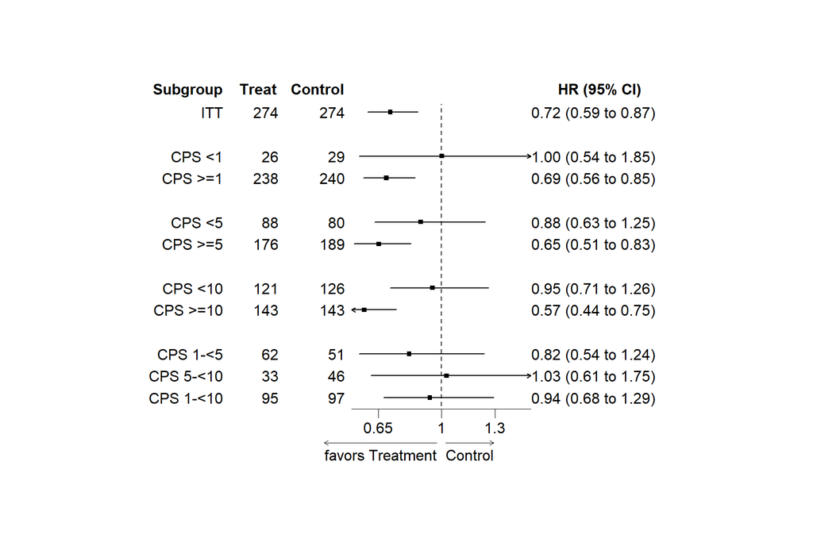

## Brief Overview of Methods

- *forestSearch* (León et al. (2024)):
  - Subgroups (SGs) with HR estimates indicative of “sub-optimal benefit” (e.g., $hr \geq 1.0$ threshold), are considered candidates with a “splitting consistency criteria” for selection[^1].
    - In essence, if a subgroup that appears to derive the least benefit is identified, then the complement may potentially be considered to derive benefit with a “higher degree of confidence” relative to the ITT population
  - SGs are formed by single factors (eg, SG1 = males, SG2 = age<65) and two-way combinations (e.g., SG3 = males & age<65)
  - SGs with a minimum size of $60$ and with a minimum of number of 10 events in each treatment arm will be considered
  - Reversing the role of treatment allows for identifying subgroups with “enhanced benefit” (e.g., $hr \leq 0.65$ threshold)
  - Continuous factors are cut at either medians (q2), or quartiles (q1, q2, q3, say)
  - Cuts are also identified by generalized random forests (GRF) which is an identification approach itself –
- *Generalized random forests* (Athey, Tibshirani, and Wager (2019), Cui et al. (2023)) which is based on restricted mean survival time (RMST) comparisons as implemented in the R package Tibshirani et al. (2022):
  - An RMST benefit of (at least) $3$ months for control is required for selection of a subgroup, where among tree depths of 1 and 2 the subgroup with the largest RMST benefit ($\geq 3$ months in favor of control) is selected
  - Similar to forestSearch, we are targeting relatively large effects
  - SGs with sample sizes of at least $60$ participants and a maximum tree depth of 2 is required

### Summary of baseline factors evaluated

|  | Pembro+CT (N=264) | CT (N=269) | Overall (N=533) |
| --- | --- | --- | --- |
| cps |  |  |  |
| Mean (SD) | 21.9 (27.1) | 18.3 (23.9) | 20.1 (25.6) |
| Median [Min, Max] | 10.0 [0, 100] | 10.0 [0, 100] | 10.0 [0, 100] |
| age |  |  |  |
| Mean (SD) | 62.9 (8.96) | 63.0 (8.51) | 63.0 (8.73) |
| Median [Min, Max] | 63.0 [32.0, 94.0] | 63.0 [35.0, 89.0] | 63.0 [32.0, 94.0] |
| tmrsize |  |  |  |
| Mean (SD) | 63.1 (46.8) | 60.9 (45.4) | 62.0 (46.1) |
| Median [Min, Max] | 51.5 [10.0, 299] | 50.0 [11.0, 272] | 50.0 [10.0, 299] |
| male |  |  |  |
| Mean (SD) | 0.814 (0.390) | 0.848 (0.360) | 0.831 (0.375) |
| Median [Min, Max] | 1.00 [0, 1.00] | 1.00 [0, 1.00] | 1.00 [0, 1.00] |
| adeno |  |  |  |
| Mean (SD) | 0 (0) | 0 (0) | 0 (0) |
| Median [Min, Max] | 0 [0, 0] | 0 [0, 0] | 0 [0, 0] |
| ecog0 |  |  |  |
| Mean (SD) | 0.371 (0.484) | 0.379 (0.486) | 0.375 (0.485) |
| Median [Min, Max] | 0 [0, 1.00] | 0 [0, 1.00] | 0 [0, 1.00] |
| livermets |  |  |  |
| Mean (SD) | 0.277 (0.448) | 0.268 (0.444) | 0.272 (0.445) |
| Median [Min, Max] | 0 [0, 1.00] | 0 [0, 1.00] | 0 [0, 1.00] |
| metastatic |  |  |  |
| Mean (SD) | 0.928 (0.259) | 0.888 (0.315) | 0.908 (0.289) |
| Median [Min, Max] | 1.00 [0, 1.00] | 1.00 [0, 1.00] | 1.00 [0, 1.00] |
| asia |  |  |  |
| Mean (SD) | 0.655 (0.476) | 0.662 (0.474) | 0.659 (0.475) |
| Median [Min, Max] | 1.00 [0, 1.00] | 1.00 [0, 1.00] | 1.00 [0, 1.00] |
| cps_1 |  |  |  |
| Mean (SD) | 0.902 (0.299) | 0.892 (0.311) | 0.897 (0.304) |
| Median [Min, Max] | 1.00 [0, 1.00] | 1.00 [0, 1.00] | 1.00 [0, 1.00] |
| cps_5 |  |  |  |
| Mean (SD) | 0.667 (0.472) | 0.703 (0.458) | 0.685 (0.465) |
| Median [Min, Max] | 1.00 [0, 1.00] | 1.00 [0, 1.00] | 1.00 [0, 1.00] |
| cps_10 |  |  |  |
| Mean (SD) | 0.542 (0.499) | 0.532 (0.500) | 0.537 (0.499) |
| Median [Min, Max] | 1.00 [0, 1.00] | 1.00 [0, 1.00] | 1.00 [0, 1.00] |

### Foresplot: Individual factors evaluated

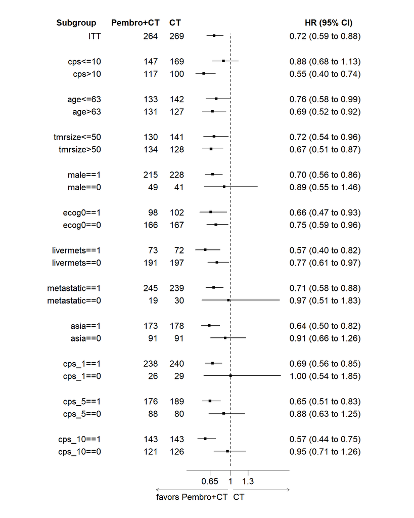

### OS Subgroups Identified

Note that hazard ratio estimates for post-hoc subgroups are adjusted for the selection algorithm and denoted as “full-analysis”

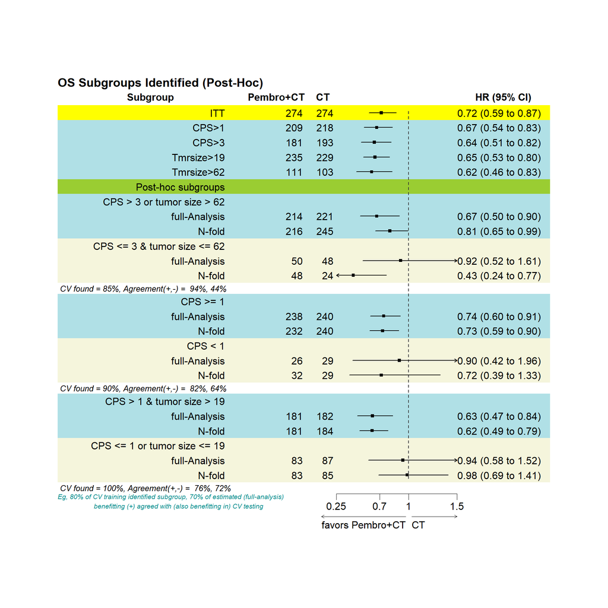

### Example of cross-validation (CV)

Cross-validation is utilized to evaluate the quality and stability (``internal reproducibility’’) of the subgroup identification algorithm.

The identified subgroup of **subjects with CPS>1 and tumor size (tmrsize) > 19** are classified as a **Benefitting (B say)** subgroup based on a forest search algorithm aimed at identifying subgroups with enhanced treatment effects. Let $\hat{B}$ denote this subgroup. To assess the internal reproducibility, the overall (ITT) population is **randomly** partitioned into 20 non-overlapping segments where for each segment (representing $\approx 5\%$ of the data) the subjects within the partition are left out of the analysis and the subgroup analysis is conducted based on the remaining 19 segments ($\approx 95\%$ of the data). Let $\hat{B}^{cv}$ denote the subgroup identified in the cross-validation analysis. For each subject (belonging to one of the 20 segments) we therefore have their classification: Whether they are within $\hat{B}^{cv}$ or not (its complement) corresponding to the segment for which they were left out of the subgroup identification analysis.

Now, for each subject left out of the analysis they were either in the original $\hat{B}$ subgroup or not (the complement $\hat{Q}$, say); Whereas, based on the cross-validation analysis, they are classified as benefiting if in the $\hat{B}^{cv}$ subgroup (or not). If a subject is in both $\hat{B}$ and $\hat{B}^{cv}$ then they are classified as benefiting in both the original and cross-validation analyses (Note that the definition of $\hat{B}$ and $\hat{B}^{cv}$ may not generally be the same). We define the sensitivity of the algorithm for $\hat{B}$ as

$$sens(\hat{B}) = {\# \left\{i \in
\hat{B} \cap \hat{B}^{cv} \right\}} / \# \left\{i \in \hat{B} \right\},$$

which represents the *proportion of subjects classified as benefiting who were also classified as benefiting (agreement) in the cross-validation analysis* (where they were not used in the identification analysis). Define the analogous measure for the complement

$$sens(\hat{Q}) = {\# \left\{i \in
\hat{Q} \cap \hat{Q}^{cv} \right\}} / \# \left\{i \in \hat{Q} \right\}.$$

Since it is possible for a cross-validation analysis to NOT identify a subgroup, in which case — in the absence of identifying a subgroup with an enhanced treatment effect — $\hat{B}^{cv}$ is set to be the empty set $\emptyset$ with all subjects classified in $\hat{Q}$ (the ITT population). Note that in these cases the identification analysis criteria is not met in the cross-validation analysis sample.

We summarize the results for a *single* cross-validation iteration for $\hat{B}$ corresponding to **subjects with CPS>1 & tmrsize>19**: Among the $20$ cross-validation analyses 20 identified a subgroup (100%); of which 5/20 (25%) were defined exactly as the full analysis (**CPS>1 & tmrsize>19**), 1/20 were defined as **CPS>1 and tmrsize>28.2**, 1/20 defined as **CPS>2.5 and tmrsize>19**, 5/20 defined as **Asia and Male**, 2/20 defined as **CPS>=10**, 1/20 defined as **CPS>=1 & Asia**, 1/20 defined as **CPS>3 & Metastatic**, 1/20 defined as **CPS>2 and Male**, 1/20 as **Tmrsize>19 and Asia**, and 2/20 defined as **Tmrsize>19 & Age<=71**. There were 363 subjects in $\hat{B}$, of which 285 were also in $\hat{B}^{cv}$; The agreement in the benefiting classification is $sens(\hat{B})$ = 79%. For the complement, there were 170 subjects in $\hat{Q}$, of which 126 were also in $\hat{Q}^{cv}$; The agreement in the complementary classification is $sens(\hat{Q})$ = 74%.

Since cross-validation results will generally depend on the random partition, we repeat the cross-validation analysis across 5 repetitions and report the medians of the summaries.

### KM Difference plots: ITT and subgroups

Note that these estimates are not adjusted for SGs

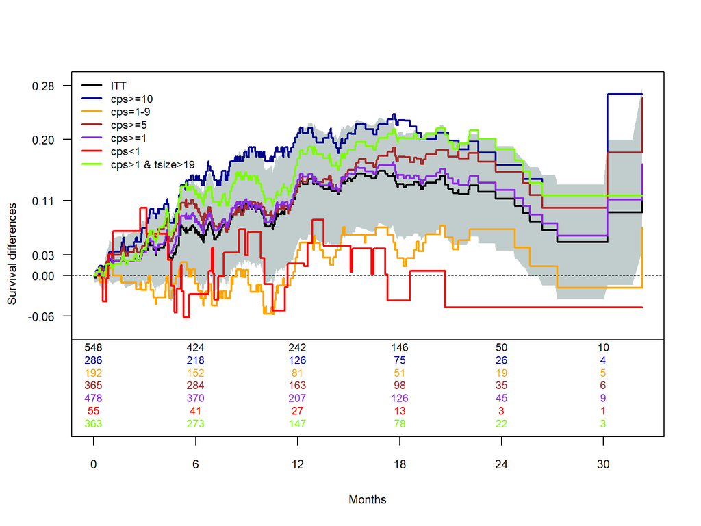

# References

Athey, Susan, Julie Tibshirani, and Stefan Wager. 2019. “Generalized Random Forests.” *The Annals of Statistics* 47 (2): 1148–78.

Cui, Yifan, Michael R Kosorok, Erik Sverdrup, Stefan Wager, and Ruoqing Zhu. 2023. “Estimating heterogeneous treatment effects with right-censored data via causal survival forests.” *Journal of the Royal Statistical Society Series B: Statistical Methodology*, February.

León, Larry F., Thomas Jemielita, Zifang Guo, Rachel Marceau West, and Keaven M. Anderson. 2024. “Exploratory Subgroup Identification in the Heterogeneous Cox Model: A Relatively Simple Procedure.” *Statistics in Medicine* 43 (20): 3921–42. https://doi.org/https://doi.org/10.1002/sim.10163.

Tibshirani, Julie, Susan Athey, Rina Friedberg, Vitor Hadad, David Hirshberg, Luke Miner, Erik Sverdrup, Stefan Wager, and Marvin Wright. 2022. “Package Grf.”

[^1]: “splitting consistency criteria” judges the robustness/realness